# Univeristy of Washington GPA Report

Yuheng Zhong, Keyan Ding, Chloe Chen, Nicholas Xu

11/08/2019

## Introduction

This study is an exciting topic regarding UW courses and could potentially reach a lot of student’s demographics. A lot of students go to sites like ratemyprofessor.com or UW’s course evaluation to learn more about the courses before they commit. Therefore, the scarcity of the information circulating leads to considerable demand for such insights. By visualizing the avg GPA of UW courses, students can better assess the difficulty of each class they are taking. It also helps to foster transparency across college courses and would help us make informed decisions to choose the right schedule.

## Summary

Influences on a student’s decision to choose a particular course to study have been popular topics of research for many educators. For this report, we gather some general information that a student will need when deciding his/her enrollment. We are only concerned with class within Info department in this report. As indicated by the dataset, the biggest class in student enrollment is INFO 200 INTELL FOUNDATIONS. Boiko’s INFO 101 A SOCIAL NETWORKING has a total of 14 students withdrawed or failedis the class that has the greatest number of Drop/Fail. Freeman’s INFO 343 A CLIENT-SIDE WEB DEV has an average GPA of 2.5 is the info class that has the lowest average class gpa, while the class with most 4.0 in percentage is INFO 365. Additionally, professor rating is also an important factor in deciding which course to take. Lastly, we find out that the professor with the highest rating is: Chen Jolie Y.

## Table

For the summary table, we choose to summarize the dataset by the popularity of classes. The popularity of class will be based on the student count of individual class. The most popular class will be the class with the largest student count number. We want to use this table to provide a insight of enrollment statistics of each informatics classes and student’s preferences among these classes. As indicated in the table, the most popular class is INFO 200 INTELL FOUNDATIONS which has a total student enrollment of 6678. The least popular class is INFO 245: DB MGMT FNDMNTLS II which only has a total student enrollment of 18.

| Course | Title | Class Popularity |
| --- | --- | --- |
| INFO 200 | INTELL FOUNDATIONS | 6678 |
| INFO 101 | SOCIAL NETWORKING | 3013 |
| INFO 490 | CAPSTONE PROJECT I | 2632 |
| INFO 360 | DESIGN THINKING | 2390 |
| INFO 498 | TOPIC INFORMATICS | 2138 |
| INFO 470 | RES METHODS IN INFO | 1869 |
| INFO 450 | INFO ETHICS & POLCY | 1792 |
| INFO 481 | PROJECT MANAGEMENT | 1716 |
| INFO 340 | RELATNL DB MGMT SYS | 1550 |
| INFO 201 | TECH FOUNDATIONS | 1547 |
| INFO 343 | CLIENT-SIDE WEB DEV | 1517 |
| INFO 102 | GENDER & INFO TECH | 1221 |
| INFO 491 | CAPSTONE PROJECT II | 1095 |
| INFO 380 | IS ANALYSIS & DSGN | 850 |
| INFO 445 | ADV DBMS DESIGN | 768 |
| INFO 330 | UX & INFO ARCH | 703 |
| INFO 330 | INFO STUCTURES | 664 |
| INFO 341 | COMP NET & DIST APP | 603 |
| INFO 340 | DBM & INFO RET SYS | 601 |
| INFO 344 | SERVER-SIDE WEB DEV | 540 |
| INFO 386 | PROFESSIONALISM | 534 |
| INFO 424 | INFO VIS & AESTH | 504 |
| INFO 370 | INTRO DATA SCIENCE | 501 |
| INFO 343 | WEB TECHNOLOGIES | 488 |
| INFO 362 | VISUAL INFO DESIGN | 482 |
| INFO 380 | IS ANALYSIS & MGMT | 474 |
| INFO 310 | INFO ASSR & CYBRSEC | 459 |
| INFO 466 | IMMERSIVE ENVIRMNTS | 452 |
| INFO 100 | COMPUTER FLUENCY | 422 |
| INFO 360 | DESIGN METHODS | 366 |
| INFO 344 | WEB TOOLS & DEV | 298 |
| INFO 312 | ENTRPRISE RISK MGMT | 275 |
| INFO 474 | INTERACTIVE INFO VIS | 271 |
| INFO 270 | DATA RSNG DIGIT WRLD | 262 |
| INFO 198 | EXPLORING INFORM | 256 |
| INFO 415 | TOPICS IN CYBERSEC | 243 |
| INFO 300 | RESEARCH METHODS | 227 |
| INFO 433 | CONTENT STRATEGY | 214 |
| INFO 463 | INPUT & INTERACTION | 212 |
| INFO 448 | ANDROID MOBILE DEV | 206 |
| INFO 490 | DSGN DEV INTER SYS | 204 |
| INFO 371 | DATA SCIENCE METHDS | 189 |
| INFO 444 | VAL SEN DESIGN | 178 |
| INFO 320 | INFO NEEDS SRCHING | 169 |
| INFO 340 | CLIENT-SIDE DEV | 151 |
| INFO 461 | COOP SOFTWARE DSGN | 150 |
| INFO 449 | IOS MOBILE DEV | 144 |
| INFO 330 | DB & DATA MODELING | 143 |
| INFO 180 | INTRO DATA SCIENCE | 132 |
| INFO 365 | MOBILE APP DESIGN | 110 |
| INFO 447 | COMP SUPP COOP WRK | 109 |
| INFO 467 | IMMERSIVE ENVIR DSN | 108 |
| INFO 370 | DATA SCIENCE METHDS | 102 |
| INFO 102 | WOMEN IN TECHNOLOGY | 94 |
| INFO 360 | USER-CTR DESIGN | 77 |
| INFO 431 | METADATA DESIGN | 77 |
| INFO 402 | GENDER, EQUITY & IT | 64 |
| INFO 310 | IAC FOUNDATIONS | 37 |
| INFO 240 | DB MGMT FNDMNTLS I | 34 |
| INFO 430 | DB DESIGN & MGMT | 34 |
| INFO 461 | COOPERTIV USR-CNTR | 26 |
| INFO 441 | SERVER-SIDE DEV | 22 |
| INFO 245 | DB MGMT FNDMNTLS II | 18 |

## Charts

### Chart 1 - Average Drop / Fail rate for INFO courses

Firstly we want to find out the hardest courses in Informatics by examining the number of students who withdraw or fail in the class. In this analysis, we define all the students who either withdraw or fail on the course to be unable to finish the course normally. Thus, by comparing the total attended students and the number of withdrawing/drop, we can calculate and compare the difficulty of each course. For this chart, we pulled ten examples with the highest drop and failed rates among all the Info courses. According to the result, INFO 441 is the most challenging course that approximately 18% of the students will either drop or fail in the class.

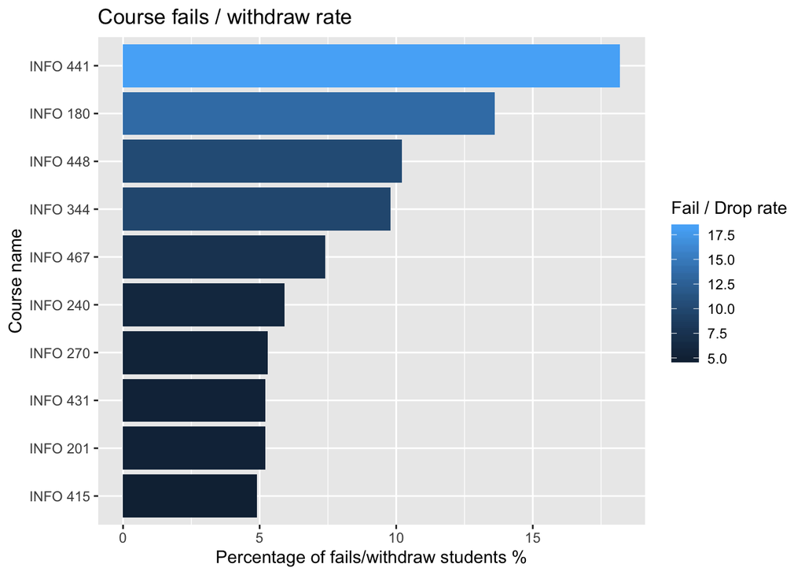

### Chart 2 - Average GPAs for INFO courses

Next we want to include a high-level overview of students’ performance on all the 100 - 400 level INFO courses from 2010 autumn to 2018 autumn. We first define “students’ performance” to be the average GPA score, since the mean value is a good indicator of performance here and we have access to the average GPA data for each INFO course at each its operating quarter and year, so we can easily compute the final average GPA score of each course for all its operating quarters. We then chose the scatterplot as our visualization tool for the aforementioned aim, since each data point we want to plot, which is the average GPA for the according course, can be easily represented by a circle/marker. And after placing all the markers on a scatterplot, we are able to see the change of performance as the course level proceeds. Another important motive is we want to give the readers an insight of the average size of each course, and this can be easily accomplished by just decr/increasing the radius of each marker!

[interactive chart not shown]

From the chart, we observed that intro courses generally have a bigger class size. In specific, INFO 101, 102, 198, 200, 201, 270, 300 are significant in their class size. For the courses in the middle i.e. intermediate level courses, class sizes are getting much smaller to around 30 except for INFO 380, with two different titles in the past, which had an average class size of approximately 120. Lastly for the upper division courses, their size are kept small to around 30 as well but with a few more exceptions: INFO 450, 470, 490, 491, which have an average class size ranging from 68 to all the way 139. The average GPAs for INFO courses are between 3.3 to 3.9, where the least value is held by INFO 180, 344, 447, 461 and the most is held by INFO 365 and 491.

### Chart 3 - GPA distribution across info200 class

**Why to use a stacked bar chart?**

The reason to include this graph is that it explains the grading disparity across sections. With fixed length across different sections, we can easily visualize which professor’s class has more A than the other in terms of percentage. Using stacked bar chart we can clearly see some professor gives eaiser grades on the class. Other charting options could not communicate grade proportioan effectively and clearly.

[interactive chart not shown]

**What information does it reveal?**

This graph shows each letter grades given from all professors of INFO 200. For example, the majority of the Chapin’s class earned A, while very few students from Freeman’s class earned an A. From this graph, students can quickly compare which professor’s class is easier in general, and thus making an informed decision.